# Entity Resolution with Probabilistic Soft Logic (PSL)

Matheus Schmitz  
[LinkedIn](https://www.linkedin.com/in/matheusschmitz/)  
[Github Portfolio](https://matheus-schmitz.github.io/)

## 1. Merge Both Sources Into a Single Dataset with All Movies/Directors

```python
import pandas as pd
from tqdm import tqdm
```

```python
imdb = pd.read_csv('./movies1/csv_files/imdb.csv').drop_duplicates()
print(f'imdb.shape: {imdb.shape}')
imdb[['Name', 'Director']].tail(3)
```

```
imdb.shape: (6407, 13)
```

|  | Name | Director |
| --- | --- | --- |
| 6404 | The Runner | Austin Stark |
| 6405 | Free Radicals: A History of Experimental Film | Pip Chodorov |
| 6406 | Experimenter | Michael Almereyda |

```python
rotten = pd.read_csv('./movies1/csv_files/rotten_tomatoes.csv').drop_duplicates()
print(f'rotten.shape: {rotten.shape}')
rotten[['Name', 'Director']].tail(3)
```

```
rotten.shape: (7390, 17)
```

|  | Name | Director |
| --- | --- | --- |
| 7387 | 99 Homes | Ramin Bahrani |
| 7388 | Experimenter | Michael Almereyda |
| 7389 | The Gift | Joel Edgerton |

```python
all_entries_df = pd.concat([imdb[['Name', 'Director']], rotten[['Name', 'Director']]], ignore_index=True).drop_duplicates()
print(f'all_entries_df.shape: {all_entries_df.shape}')
all_entries_df.tail(3)
```

```
all_entries_df.shape: (10946, 2)
```

|  | Name | Director |
| --- | --- | --- |
| 13790 | Great Directors | Angela Ismailos |
| 13791 | Still Screaming: The Ultimate Scary Movie Retr... | Ryan Turek |
| 13793 | Adjust Your Tracking | Dan M. Kinem,Levi Peretic |

## 2. Break Entries With Multiple Directors per Movie into Multiple Entries with One Director per Movie

Reusing dataframe manipulation code from a previous project: https://matheus-schmitz.github.io/TED_Talks_Data_Analysis/

```python
# As of now, for the same Movie the Directors column has multiple director names separated by commas
# Generate multiple columns, each containing at most one director name for a given movie
movie_directors_df = pd.concat([all_entries_df[['Name']], all_entries_df['Director'].str.split(',', expand=True)], axis=1).drop_duplicates()
print(f'movie_directors_df.shape: {movie_directors_df.shape}')
movie_directors_df.tail(3)
```

```
movie_directors_df.shape: (10946, 33)
```

|  | Name | 0 | 1 | 2 | 3 | 4 | 5 | 6 | 7 | 8 | ... | 22 | 23 | 24 | 25 | 26 | 27 | 28 | 29 | 30 | 31 |
| --- | --- | --- | --- | --- | --- | --- | --- | --- | --- | --- | --- | --- | --- | --- | --- | --- | --- | --- | --- | --- | --- |
| 13790 | Great Directors | Angela Ismailos | None | None | None | None | None | None | None | None | ... | None | None | None | None | None | None | None | None | None | None |
| 13791 | Still Screaming: The Ultimate Scary Movie Retr... | Ryan Turek | None | None | None | None | None | None | None | None | ... | None | None | None | None | None | None | None | None | None | None |
| 13793 | Adjust Your Tracking | Dan M. Kinem | Levi Peretic | None | None | None | None | None | None | None | ... | None | None | None | None | None | None | None | None | None | None |

3 rows × 33 columns

```python
# Turn the data back into having a single column for Diretors, now with repeating rows for movies with more than one director
df_melted = movie_directors_df.melt(id_vars='Name').drop_duplicates()
print(f'df_melted.shape: {df_melted.shape}')
df_melted
```

```
df_melted.shape: (300074, 3)
```

|  | Name | variable | value |
| --- | --- | --- | --- |
| 0 | City of Missing Girls | 0 | Elmer Clifton |
| 1 | The Gay Divorcee | 0 | Mark Sandrich |
| 2 | The Divorcée | 0 | Robert Z. Leonard |
| 3 | Hells Angels on Wheels | 0 | Richard Rush |
| 4 | The Miracle Woman | 0 | Ketan Mehta |
| ... | ... | ... | ... |
| 350267 | Girl 27 | 31 | None |
| 350268 | American Grindhouse | 31 | None |
| 350269 | Great Directors | 31 | None |
| 350270 | Still Screaming: The Ultimate Scary Movie Retr... | 31 | None |
| 350271 | Adjust Your Tracking | 31 | None |

300074 rows × 3 columns

```python
# Clean the dataframe so gain it has only two columns: Movie and Director
df_drops = df_melted.dropna(subset=['value']).copy()
df_drops.drop(labels=['variable'], axis=1, inplace=True)
df_drops.reset_index(inplace=True, drop=True)
df_drops.columns = ['Movie', 'Director']
df_drops.drop_duplicates(inplace=True)
print(f'df_drops.shape: {df_drops.shape}')
df_drops.tail(3)
```

```
df_drops.shape: (13125, 2)
```

|  | Movie | Director |
| --- | --- | --- |
| 13650 | The ABCs of Death | Simon Barrette |
| 13651 | ABCs of Death 2 | Vincenzo Natali |
| 13652 | The ABCs of Death | Simon Barrett |

```python
# Strip extra whitespaces from names as that was causing errors down the line
df_drops = df_drops.apply(lambda s: s.str.strip())
print(f'df_drops.shape: {df_drops.shape}')
df_drops.tail(3)
```

```
df_drops.shape: (13125, 2)
```

|  | Movie | Director |
| --- | --- | --- |
| 13650 | The ABCs of Death | Simon Barrette |
| 13651 | ABCs of Death 2 | Vincenzo Natali |
| 13652 | The ABCs of Death | Simon Barrett |

## 3. Generate Unique IDs

```python
# Get all unique Movie names
df_movies = df_drops['Movie'].copy()
df_movies.drop_duplicates(inplace=True)
print(f'df_movies.shape: {df_movies.shape}')
df_movies.tail(3)
```

```
df_movies.shape: (9283,)
```

```
10704                                      Great Directors
10705    Still Screaming: The Ultimate Scary Movie Retr...
10706                                 Adjust Your Tracking
Name: Movie, dtype: object
```

```python
# Generate IDs for movies
ID_to_movie = {}
movie_to_ID = {}
for idx, item in df_movies.iteritems():
    ID_to_movie[idx] = item
    movie_to_ID[item] = idx
```

```python
# Get all unique Director names
df_directors = df_drops['Director'].copy()
df_directors.drop_duplicates(inplace=True)
print(f'df_directors.shape: {df_directors.shape}')
df_directors.tail(3)
```

```
df_directors.shape: (7122,)
```

```
13649         Todd Rohal
13650     Simon Barrette
13651    Vincenzo Natali
Name: Director, dtype: object
```

```python
# Generate IDs for directors (start at 50000 to avoid bumping into movie IDs)
ID_to_director = {}
director_to_ID = {}
for idx, item in df_directors.iteritems():
    ID_to_director[idx + 50000] = item
    director_to_ID[item] = idx + 50000
```

```python
# Plug the IDs back into the DataFrame with Movie/Director
df_ids = pd.DataFrame(columns = ['Movie', 'Director', 'Movie_ID', 'Director_ID'])

for idx, row in tqdm(df_drops.iterrows(), total=df_drops.shape[0]):

    df_ids = df_ids.append({'Movie': row.Movie,
                            'Director': row.Director,
                            'Movie_ID': movie_to_ID[row.Movie],
                            'Director_ID': director_to_ID[row.Director]},
                           ignore_index=True)

print(f'df_ids.shape: {df_ids.shape}')
df_ids.tail(3)
```

```
df_ids.shape: (13125, 4)
```

|  | Movie | Director | Movie_ID | Director_ID |
| --- | --- | --- | --- | --- |
| 13122 | The ABCs of Death | Simon Barrette | 5538 | 63650 |
| 13123 | ABCs of Death 2 | Vincenzo Natali | 5540 | 63651 |
| 13124 | The ABCs of Death | Simon Barrett | 5538 | 55545 |

## 4. Generate Blocks

```python
import string
```

```python
# Function to block based on first letter of each word in the string, ignoring numbers (Ice Age x Ice Age 2 get the same block)
# Also ignore "The" in the movie names, as that is often withheld from titles, which can mess with blocks
def generate_blocks(full_name):
    block = ''.join(sorted([s[0].upper() for s in full_name.split() if s != "The" and s != "the"]))
    # Strip number from the block as long as it won't result in a Null block
    if len(block.strip('0123456789')) > 0:
        block = block.strip('0123456789')
    return block

# There are some missing values represented as "???" which become None if stripping all punction, which then generates errors
def strip_punctuation_all(s):
    return s.translate(str.maketrans('', '', string.punctuation))

# Stripping just certain punctuations for text clearning
def strip_punctuation_selective(s):
    s = s.replace('.', ' ')
    s = s.replace('(', ' ')
    s = s.replace(')', ' ')
    s = s.strip()
    return s
```

```python
# For generating director blocks, ensure that names with initials are used too
df_ids['DirectorBlock'] = df_ids['Director'].apply(strip_punctuation_selective).apply(generate_blocks)
df_ids['MovieBlock'] = df_ids['Movie'].apply(strip_punctuation_selective).apply(generate_blocks)
df_ids.tail(3)
```

|  | Movie | Director | Movie_ID | Director_ID | DirectorBlock | MovieBlock |
| --- | --- | --- | --- | --- | --- | --- |
| 13122 | The ABCs of Death | Simon Barrette | 5538 | 63650 | BS | ADO |
| 13123 | ABCs of Death 2 | Vincenzo Natali | 5540 | 63651 | NV | ADO |
| 13124 | The ABCs of Death | Simon Barrett | 5538 | 55545 | BS | ADO |

## 5. Create Observation Files

```python
directorBlock_obs = df_ids[['Director_ID', 'DirectorBlock']].drop_duplicates()
directorBlock_obs.to_csv('full_directorBlock_obs.txt', sep='\t', header=False, index=False)
print(f'directorBlock_obs.shape: {directorBlock_obs.shape}')
```

```
directorBlock_obs.shape: (7122, 2)
```

```python
directorName_obs = df_ids[['Director_ID', 'Director']].drop_duplicates()
directorName_obs.to_csv('full_directorName_obs.txt', sep='\t', header=False, index=False)
print(f'directorName_obs.shape: {directorName_obs.shape}')
```

```
directorName_obs.shape: (7122, 2)
```

```python
directorOf_obs = df_ids[['Director_ID', 'Movie_ID']].drop_duplicates()
directorOf_obs.to_csv('full_directorOf_obs.txt', sep='\t', header=False, index=False)
print(f'directorOf_obs.shape: {directorOf_obs.shape}')
```

```
directorOf_obs.shape: (13125, 2)
```

```python
movieBlock_obs = df_ids[['Movie_ID', 'MovieBlock']].drop_duplicates()
movieBlock_obs.to_csv('full_movieBlock_obs.txt', sep='\t', header=False, index=False)
print(f'movieBlock_obs.shape: {movieBlock_obs.shape}')
```

```
movieBlock_obs.shape: (9283, 2)
```

```python
movieTitle_obs = df_ids[['Movie_ID', 'Movie']].drop_duplicates()
movieTitle_obs.to_csv('full_movieTitle_obs.txt', sep='\t', header=False, index=False)
print(f'movieTitle_obs.shape: {movieTitle_obs.shape}')
```

```
movieTitle_obs.shape: (9283, 2)
```

## 6. Calculate String Similarities

```python
from strsimpy.jaro_winkler import JaroWinkler
from strsimpy.normalized_levenshtein import NormalizedLevenshtein
```

```python
jaro_winkler = JaroWinkler().similarity

with open('full_simDirector_obs.txt', 'w') as f_out:

    # Iterate over blocks
    for block in tqdm(df_ids['DirectorBlock'].unique()):

        # Then do pairwise comparison for all items on the current block
        for left_item in df_ids[df_ids['DirectorBlock'] == block]['Director'].unique():
            for right_item in df_ids[df_ids['DirectorBlock'] == block]['Director'].unique():

                # Calculate similarity
                similarity = jaro_winkler(left_item, right_item)

                # Get IDs
                left_id = director_to_ID[left_item]
                right_id = director_to_ID[right_item]

                # And write to the similarities file
                f_out.write(f'{left_id}' + '\t' + f'{right_id}' + '\t' + f'{similarity}' + '\n')
```

```python
normalized_levenshtein = NormalizedLevenshtein().similarity

with open('full_simMovie_obs.txt', 'w') as f_out:

    # Iterate over blocks
    for block in tqdm(df_ids['MovieBlock'].unique()):

        # Then do pairwise comparison for all items on the current block
        for left_item in df_ids[df_ids['MovieBlock'] == block]['Movie'].unique():
            for right_item in df_ids[df_ids['MovieBlock'] == block]['Movie'].unique():

                # Calculate similarity
                similarity = normalized_levenshtein(left_item.lower(), right_item.lower())

                # Get IDs
                left_id = movie_to_ID[left_item]
                right_id = movie_to_ID[right_item]

                # And write to the similarities file
                f_out.write(f'{left_id}' + '\t' + f'{right_id}' + '\t' + f'{similarity}' + '\n')
```

## 7. Generate Targets From All Candidates

```python
# All pairwise comparisons for each block of Movies
with open('full_sameMovie_target.txt', 'w') as f_out:

    # Iterate over blocks
    for block in tqdm(df_ids['MovieBlock'].unique()):

        # Then do pairwise comparison for all items on the current block
        for left_item in df_ids[df_ids['MovieBlock'] == block]['Movie_ID'].unique():
            for right_item in df_ids[df_ids['MovieBlock'] == block]['Movie_ID'].unique():

                # And write to the similarities file
                f_out.write(f'{left_item}' + '\t' + f'{right_item}' + '\n')
```

```python
# All pairwise comparisons for each block of Directors
with open('full_sameDirector_target.txt', 'w') as f_out:

    # Iterate over blocks
    for block in tqdm(df_ids['DirectorBlock'].unique()):

        # Then do pairwise comparison for all items on the current block
        for left_item in df_ids[df_ids['DirectorBlock'] == block]['Director_ID'].unique():
            for right_item in df_ids[df_ids['DirectorBlock'] == block]['Director_ID'].unique():

                # And write to the similarities file
                f_out.write(f'{left_item}' + '\t' + f'{right_item}' + '\n')
```

## 8. Generate Truth from Labeled Data

According to the thread "Multiple Directors" on BlackBoard, we only need to evaluate on movies.

```python
labeled = pd.read_csv('./movies1/csv_files/labeled_data.csv', skiprows=5)
print(f'labeled.shape: {labeled.shape}')
labeled.tail(3)
```

```
labeled.shape: (600, 10)
```

|  | _id | ltable.Id | rtable.Id | ltable.Director | ltable.Name | ltable.Year | rtable.Director | rtable.Name | rtable.YearRange | gold |
| --- | --- | --- | --- | --- | --- | --- | --- | --- | --- | --- |
| 597 | 11103 | tt4562728 | the_divergent_series_allegiant | Robert Schwartzman | MF | 2015 | Robert Schwentke | The Divergent Series: Allegiant | 2015 2016 2017 | 0 |
| 598 | 11120 | tt4795692 | sisters_2015 | Sean Hanish | Sister Cities | 2016 | Em Cooper,Jason Moore | Sisters | 2014 2015 2016 | 0 |
| 599 | 11138 | tt4984930 | the_mend | Su Rynard | The Messenger | 2015 | John Magary | The Mend | 2014 2015 2016 | 0 |

```python
# Get a dataframe with only the movie matchings and their gold labels
labeled_movie = labeled[['ltable.Name', 'rtable.Name', 'gold']]
print(f'labeled_movie.shape: {labeled_movie.shape}')
labeled_movie.tail(3)
```

```
labeled_movie.shape: (600, 3)
```

|  | ltable.Name | rtable.Name | gold |
| --- | --- | --- | --- |
| 597 | MF | The Divergent Series: Allegiant | 0 |
| 598 | Sister Cities | Sisters | 0 |
| 599 | The Messenger | The Mend | 0 |

```python
# Encode the labeled_movie DataFrame into IDs
labeled_movie_IDs = pd.DataFrame(columns = ['l_movie_id', 'r_movie_id', 'gold'])

for idx, row in labeled_movie.iterrows():

    # There is one movie "Dj Vu" which somehow is on the labeled dataset but not on either of the original source datasets
    # It will generate an error, so I'm just skipping that one movie
    try:
        labeled_movie_IDs = labeled_movie_IDs.append({'l_movie_id': movie_to_ID[row["ltable.Name"]],
                                                      'r_movie_id': movie_to_ID[row["rtable.Name"]],
                                                      'gold': row.gold}, ignore_index=True)
    except:
        pass

# There is also one entry which seems to be duplicate and can cause errors later
labeled_movie_IDs.drop_duplicates(inplace=True)
print(f'labeled_movie_IDs.shape: {labeled_movie_IDs.shape}')
labeled_movie_IDs.tail(3)
```

```
labeled_movie_IDs.shape: (598, 3)
```

|  | l_movie_id | r_movie_id | gold |
| --- | --- | --- | --- |
| 596 | 7356 | 5865 | 0 |
| 597 | 8344 | 263 | 0 |
| 598 | 6158 | 582 | 0 |

```python
# Save as a "tab-separated .txt" file which is what PSL requires

# Truth
labeled_movie_IDs.to_csv('labeled_sameMovie_truth.txt', sep='\t', header=False, index=False)

# Target
labeled_movie_IDs.drop('gold', axis=1).to_csv('labeled_sameMovie_target.txt', sep='\t', header=False, index=False)
```

## 9. Generate Downsampled Files

Using all samples in the candidate dataset was generating a file too large for my computer to handle. So one reasonable approach is to downsample the data while ensuring that all samples from the labeled dataset are present in the downsampled version. The samples outiside the labeled dataset are still important at they help the Collective KG-based ER Rules, but since using all of them proved too much, then downsampling them instead of removing them is a reasonable compromise.

```python
# First downsample the DataFrame with all candidates
df_ids_downsampled = df_ids.sample(frac=0.5)
print(f'df_ids_downsampled.shape: {df_ids_downsampled.shape}')
df_ids_downsampled.tail(3)
```

```
df_ids_downsampled.shape: (6562, 6)
```

|  | Movie | Director | Movie_ID | Director_ID | DirectorBlock | MovieBlock |
| --- | --- | --- | --- | --- | --- | --- |
| 10126 | Creative Control | Benjamin Dickinson | 10126 | 60126 | BD | CC |
| 1099 | The Dark Knight | Christopher Nolan | 1099 | 51089 | CN | DK |
| 10772 | Bambi | Graham Heid | 361 | 60793 | GH | B |

```python
# Then add all pairs in the labeled data to the downsampled DataFrame
for idx, row in tqdm(labeled_movie_IDs.iterrows(), total=labeled_movie_IDs.shape[0]):

    # Fetch the movie names
    left_movie_name = ID_to_movie[row.l_movie_id]
    right_movie_name = ID_to_movie[row.r_movie_id]

    # Fetch the director IDs
    left_director_id = directorOf_obs[directorOf_obs['Movie_ID'] == row.l_movie_id].Director_ID.values[0]
    right_director_id = directorOf_obs[directorOf_obs['Movie_ID'] == row.r_movie_id].Director_ID.values[0]

    # Fetch director names
    left_director_name = ID_to_director[left_director_id]
    right_director_name = ID_to_director[right_director_id]

    # Generate director blocks
    left_director_block = pd.Series(left_director_name).apply(strip_punctuation_selective).apply(generate_blocks)[0]
    right_director_block = pd.Series(right_director_name).apply(strip_punctuation_selective).apply(generate_blocks)[0]

    # Generate movie blocks
    left_movie_block = pd.Series(left_movie_name).apply(strip_punctuation_selective).apply(generate_blocks)[0]
    right_movie_block = pd.Series(right_movie_name).apply(strip_punctuation_selective).apply(generate_blocks)[0]

    # Create one dictionary per movie (left and right)
    left_dict = {'Movie': left_movie_name,
                 'Director': left_director_name,
                 'Movie_ID': row.l_movie_id,
                 'Director_ID': left_director_id,
                 'DirectorBlock': left_director_block,
                 'MovieBlock': left_movie_block}

    right_dict = {'Movie': right_movie_name,
                  'Director': right_director_name,
                  'Movie_ID': row.r_movie_id,
                  'Director_ID': right_director_id,
                  'DirectorBlock': right_director_block,
                  'MovieBlock': right_movie_block}

    # Append both samples to the downsamples DataFrame
    df_ids_downsampled = df_ids_downsampled.append([left_dict, right_dict], ignore_index=True)

# Appending dictionaries changes the column types to "object", return them to proper types
df_ids_downsampled = df_ids_downsampled.astype('string')
df_ids_downsampled['Movie_ID'] = df_ids_downsampled['Movie_ID'].astype('int')
df_ids_downsampled['Director_ID'] = df_ids_downsampled['Director_ID'].astype('int')

# Remove any duplicates in the downsampled DataFrame
df_ids_downsampled.drop_duplicates(inplace=True)
print(f'df_ids_downsampled.shape: {df_ids_downsampled.shape}')
df_ids_downsampled.tail(3)
```

```
df_ids_downsampled.shape: (7004, 6)
```

|  | Movie | Director | Movie_ID | Director_ID | DirectorBlock | MovieBlock |
| --- | --- | --- | --- | --- | --- | --- |
| 7751 | The Metropolitan Opera: Cavalleria Rusticana/p... | David McVicar | 3278 | 53278 | DM | CMOR |
| 7753 | The Divergent Series: Allegiant | Robert Schwentke | 5865 | 55103 | RS | ADS |
| 7756 | The Messenger | Oren Moverman | 6158 | 53979 | MO | M |

**Filter All Files Based on IDs on the Downsampled File**

```python
# All pairwise comparisons for each downsampled block of Movies
with open('downsampled_sameMovie_target.txt', 'w') as f_out:

    # Iterate over blocks
    for block in tqdm(df_ids_downsampled['MovieBlock'].unique()):

        # Then do pairwise comparison for all items on the current block
        for left_item in df_ids_downsampled[df_ids_downsampled['MovieBlock'] == block]['Movie_ID'].unique():
            for right_item in df_ids_downsampled[df_ids_downsampled['MovieBlock'] == block]['Movie_ID'].unique():

                # And write to the similarities file
                f_out.write(f'{left_item}' + '\t' + f'{right_item}' + '\n')
```

```python
# All pairwise comparisons for each downsampled block of Directors
with open('downsampled_sameDirector_target.txt', 'w') as f_out:

    # Iterate over blocks
    for block in tqdm(df_ids_downsampled['DirectorBlock'].unique()):

        # Then do pairwise comparison for all items on the current block
        for left_item in df_ids_downsampled[df_ids_downsampled['DirectorBlock'] == block]['Director_ID'].unique():
            for right_item in df_ids_downsampled[df_ids_downsampled['DirectorBlock'] == block]['Director_ID'].unique():

                # And write to the similarities file
                f_out.write(f'{left_item}' + '\t' + f'{right_item}' + '\n')
```

```python
downsampled_directorBlock_obs = directorBlock_obs[directorBlock_obs['Director_ID'].isin(df_ids_downsampled['Director_ID'].values)]
downsampled_directorBlock_obs.to_csv('downsampled_directorBlock_obs.txt', sep='\t', header=False, index=False)
print(f'downsampled_directorBlock_obs.shape: {downsampled_directorBlock_obs.shape}')
```

```
downsampled_directorBlock_obs.shape: (4452, 2)
```

```python
downsampled_directorName_obs = directorName_obs[directorName_obs['Director_ID'].isin(df_ids_downsampled['Director_ID'].values)]
downsampled_directorName_obs.to_csv('downsampled_directorName_obs.txt', sep='\t', header=False, index=False)
print(f'downsampled_directorName_obs.shape: {downsampled_directorName_obs.shape}')
```

```
downsampled_directorName_obs.shape: (4452, 2)
```

```python
downsampled_directorOf_obs = directorOf_obs[directorOf_obs['Director_ID'].isin(df_ids_downsampled['Director_ID'].values) | directorOf_obs['Movie_ID'].isin(df_ids_downsampled['Movie_ID'].values)]
downsampled_directorOf_obs.to_csv('downsampled_directorOf_obs.txt', sep='\t', header=False, index=False)
print(f'downsampled_directorOf_obs.shape: {downsampled_directorOf_obs.shape}')
```

```
downsampled_directorOf_obs.shape: (11331, 2)
```

```python
downsampled_movieBlock_obs = movieBlock_obs[movieBlock_obs['Movie_ID'].isin(df_ids_downsampled['Movie_ID'].values)]
downsampled_movieBlock_obs.to_csv('downsampled_movieBlock_obs.txt', sep='\t', header=False, index=False)
print(f'downsampled_movieBlock_obs.shape: {downsampled_movieBlock_obs.shape}')
```

```
downsampled_movieBlock_obs.shape: (5616, 2)
```

```python
downsampled_movieTitle_obs = movieBlock_obs[movieBlock_obs['Movie_ID'].isin(df_ids_downsampled['Movie_ID'].values)]
downsampled_movieTitle_obs.to_csv('downsampled_movieTitle_obs.txt', sep='\t', header=False, index=False)
print(f'downsampled_movieTitle_obs.shape: {downsampled_movieTitle_obs.shape}')
```

```
downsampled_movieTitle_obs.shape: (5616, 2)
```

```python
jaro_winkler = JaroWinkler().similarity

with open('downsampled_simDirector_obs.txt', 'w') as f_out:

    # Iterate over blocks
    for block in tqdm(df_ids_downsampled['DirectorBlock'].unique()):

        # Then do pairwise comparison for all items on the current block
        for left_item in df_ids_downsampled[df_ids_downsampled['DirectorBlock'] == block]['Director'].unique():
            for right_item in df_ids[df_ids['DirectorBlock'] == block]['Director'].unique():

                # Calculate similarity
                similarity = jaro_winkler(left_item, right_item)

                # Get IDs
                left_id = director_to_ID[left_item]
                right_id = director_to_ID[right_item]

                # And write to the similarities file
                f_out.write(f'{left_id}' + '\t' + f'{right_id}' + '\t' + f'{similarity}' + '\n')
```

```python
normalized_levenshtein = NormalizedLevenshtein().similarity

with open('downsampled_simMovie_obs.txt', 'w') as f_out:

    # Iterate over blocks
    for block in tqdm(df_ids_downsampled['MovieBlock'].unique()):

        # Then do pairwise comparison for all items on the current block
        for left_item in df_ids_downsampled[df_ids_downsampled['MovieBlock'] == block]['Movie'].unique():
            for right_item in df_ids_downsampled[df_ids_downsampled['MovieBlock'] == block]['Movie'].unique():

                # Calculate similarity
                similarity = normalized_levenshtein(left_item.lower(), right_item.lower())

                # Get IDs
                left_id = movie_to_ID[left_item]
                right_id = movie_to_ID[right_item]

                # And write to the similarities file
                f_out.write(f'{left_id}' + '\t' + f'{right_id}' + '\t' + f'{similarity}' + '\n')
```

## 10. Define Data Structure

```python
with open("data_file.data", 'w') as data_file:
    data_file.write("""
predicates:
   DirectorName/2:
      - closed
      - types:
         - UniqueIntID
         - UniqueStringID
   DirectorBlock/2:
      - closed
      - block
      - types:
         - UniqueIntID
         - UniqueStringID
   DirectorOf/2:
      - closed
      - types:
         - UniqueIntID
         - UniqueIntID
   MovieTitle/2:
      - closed
      - types:
         - UniqueIntID
         - UniqueStringID
   MovieBlock/2:
      - closed
      - block
      - types:
         - UniqueIntID
         - UniqueStringID
   SimDirector/2:
      - closed
      - types:
         - UniqueStringID
         - UniqueStringID
   SimMovie/2:
      - closed
      - types:
         - UniqueStringID
         - UniqueStringID
   SameMovie/2:
      - open
      - types:
         - UniqueIntID
         - UniqueIntID
   SameDirector/2:
      - open
      - types:
         - UniqueIntID
         - UniqueIntID

observations:
   DirectorName: downsampled_directorName_obs.txt
   DirectorBlock: downsampled_directorBlock_obs.txt
   DirectorOf: downsampled_directorOf_obs.txt
   MovieTitle: downsampled_movieTitle_obs.txt
   MovieBlock: downsampled_movieBlock_obs.txt
   SimDirector: downsampled_simDirector_obs.txt
   SimMovie: downsampled_simMovie_obs.txt

targets:
   SameMovie: downsampled_sameMovie_target.txt
   SameDirector: downsampled_sameDirector_target.txt
""")
```

## 11. Define Probabilistic Soft Logic (PSL) Rules

```python
with open("psl_file.psl", 'w') as data_file:
    data_file.write("""
// Look for text similarity.
40.0: DirectorName(D1, N1) & DirectorName(D2, N2) & SimDirector(N1, N2) & (D1 != D2) -> SameDirector(D1, D2) ^2
40.0: MovieTitle(M1, T1) & MovieTitle(M2, T2) & SimMovie(T1, T2) & (M1 != M2) -> SameMovie(M1, M2) ^2

// Pure transitivity (Director)
20.0: DirectorBlock(D1, B) & DirectorBlock(D2, B) & DirectorBlock(D3, B)
   & SameDirector(D1, D2) & SameDirector(D2, D3)
   & (D1 != D3) & (D1 != D2) & (D2 != D3)
   -> SameDirector(D1, D3) ^2

// Pure transitivity (Movie)
20.0: MovieBlock(M1, B) & MovieBlock(M2, B) & MovieBlock(M3, B)
   & SameMovie(M1, M2) & SameMovie(M2, M3)
   & (M1 != M3) & (M1 != M2) & (M2 != M3)
   -> SameMovie(M1, M3) ^2

// Collective KG-Based ER Rules (Codirector rectangle closure)
20.0: DirectorBlock(D1, B1) & DirectorBlock(D2, B1) & DirectorBlock(CD1, B2) & DirectorBlock(CD2, B2) &
   & DirectorOf(D1, M1) & DirectorOf(D2, M2)
   & DirectorOf(CD1, M1) & DirectorOf(CD2, M2) & SameDirector(CD1, CD2)
   & (D1 != CD1) & (D2 != CD2) & (M1 != M2)
   -> SameDirector(D1, D2) ^2

// Collective KG-Based ER Rules (Movie rectangle closure)
10.0: DirectorBlock(D1, B1) & DirectorBlock(D2, B1)
   & DirectorOf(D1, M1) & DirectorOf(D2, M2)
   & SameMovie(M1, M2)
   -> SameDirector(D1, D2) ^2

// Self-refernece.
SameDirector(A, A) = 1.0 .
SameMovie(P, P) = 1.0 .

// Negative priors.
1.0: !SameDirector(D1, D2) ^2
1.0: !SameMovie(D1, D2) ^2

""")
```

## 12. Run PSL Inference

```python
%%time
# This might take a while...
!java -Xmx6g -jar psl-cli-2.2.1.jar --infer --model psl_file.psl --data data_file.data --output inferred_predicates
```

```
^C
```

## 13. Load Truth and Predictions

**Ground Truth**

```python
df_truth = pd.read_csv('labeled_sameMovie_truth.txt', sep='\t', header=None)
print(f'df_truth.shape: {df_truth.shape}')
df_truth.head(3)
```

```
df_truth.shape: (598, 3)
```

|  | 0 | 1 | 2 |
| --- | --- | --- | --- |
| 0 | 7012 | 1050 | 0 |
| 1 | 46 | 20 | 0 |
| 2 | 26 | 72 | 0 |

```python
# Convert to a dict with double index
dict_truth = {}
for idx, (idx_a, idx_b, truth) in tqdm(df_truth.iterrows(), total=df_truth.shape[0]):
    dict_truth[(int(idx_a), int(idx_b))] = int(truth)
len(dict_truth)
```

```
598
```

```python
# Crete a inverse dictionary
dict_truth_inverse = {0:[], 1:[]}
for idx, (idx_a, idx_b, truth) in tqdm(df_truth.iterrows(), total=df_truth.shape[0]):
    if truth >= 0.5:
        dict_truth_inverse[1].append((int(idx_a), int(idx_b)))
    else:
        dict_truth_inverse[0].append((int(idx_a), int(idx_b)))
len(dict_truth_inverse[0]) + len(dict_truth_inverse[1])
```

```
598
```

**Predictions**

```python
df_pred = pd.read_csv('./inferred_predicates/SAMEMOVIE.txt', sep='\t', header=None)
print(f'df_pred.shape: {df_pred.shape}')
df_pred.head(3)
```

```
df_pred.shape: (109876, 3)
```

|  | 0 | 1 | 2 |
| --- | --- | --- | --- |
| 0 | 103 | 1115 | 0.009894 |
| 1 | 13 | 4453 | 0.000428 |
| 2 | 79 | 2012 | 0.001250 |

```python
# Convert to a dict with double index
dict_pred = {}
for idx, (idx_a, idx_b, call) in tqdm(df_pred.iterrows(), total=df_pred.shape[0]):
    dict_pred[(int(idx_a), int(idx_b))] = 1 if call >= 0.5 else 0
len(dict_pred)
```

```
109876
```

```python
# Crete a inverse dictionary
dict_pred_inverse = {0:[], 1:[]}
for idx, (idx_a, idx_b, call) in tqdm(df_pred.iterrows(), total=df_pred.shape[0]):
    if call >= 0.5:
        dict_pred_inverse[1].append((int(idx_a), int(idx_b)))
    else:
        dict_pred_inverse[0].append((int(idx_a), int(idx_b)))
len(dict_pred_inverse[0]) + len(dict_pred_inverse[1])
```

```
109876
```

## 14. Evaluate PSL Model Performance

### Precision

"Of all calls I made, how many were correctly made?"

```python
TP = 0
FP = 0

# dict_pred_inverse[1] = all the calls I made
for match in dict_pred_inverse[1]:
    # Consider only the samples in the labeled dataset
    if match in dict_truth.keys():
        if dict_truth.get(match) == 1:
            TP += 1
        else:
            FP += 1

precision = TP / (TP + FP)

print(f'TP: {TP:>4}')
print(f'FP: {FP:>4}')
print(f'Precision: {precision:.5f}')
```

```
TP:  173
FP:    2
Precision: 0.98857
```

### Recall

"Of all calls I should have made, how many did I make?"

```python
TP = 0
FN = 0

# dict_truth_inverse[1] = all the calls I should have made
for match in dict_truth_inverse[1]:
    if dict_pred.get(match) == 1:
        TP += 1
    else:
        FN += 1

recall = TP / (TP + FN)

print(f'TP: {TP:>4}')
print(f'FN: {FN:>4}')
print(f'Recall: {recall:.5f}')
```

```
TP:  173
FN:   16
Recall: 0.91534
```

### F1-Score

```python
F1 = (2 * precision * recall) / (precision + recall)
print(f'F1 Score: {F1:.5f}')
```

```
F1 Score: 0.95055
```

## 15. Improve the Model by Tweaking the Classification Threshold

**Grid Search Over Classification Threshold**

```python
# DataFrame to keep track of results at each threshold
grid_search_df = pd.DataFrame(columns = ['TP', 'FP', 'FN', 'Precision', 'Recall', 'F1 Score'])

# Generate thresholds in increments of 5%
thresholds = [x/100 for x in range(0,101,5)]

# Then loop over the thresholds
for threshold in tqdm(thresholds):

    ################################
    ### Predictions Dictionaries ###
    ################################

    dict_pred = {}
    for idx, (idx_a, idx_b, call) in df_pred.iterrows():
        dict_pred[(int(idx_a), int(idx_b))] = 1 if call >= threshold else 0

    dict_pred_inverse = {0:[], 1:[]}
    for idx, (idx_a, idx_b, call) in df_pred.iterrows():
        if call >= threshold:
            dict_pred_inverse[1].append((int(idx_a), int(idx_b)))
        else:
            dict_pred_inverse[0].append((int(idx_a), int(idx_b)))


    #################
    ### Precision ###
    #################

    TP = 0
    FP = 0

    # dict_pred_inverse[1] = all the calls I made
    for match in dict_pred_inverse[1]:
        # Consider only the samples in the labeled dataset
        if match in dict_truth.keys():
            if dict_truth.get(match) == 1:
                TP += 1
            else:
                FP += 1

    precision = TP / (TP + FP)


    ##############
    ### Recall ###
    ##############

    TP = 0
    FN = 0

    # dict_truth_inverse[1] = all the calls I should have made
    for match in dict_truth_inverse[1]:
        if dict_pred.get(match) == 1:
            TP += 1
        else:
            FN += 1

    recall = TP / (TP + FN)


    ################
    ### F1-Score ###
    ################

    F1 = (2 * precision * recall) / (precision + recall)


    ########################################
    ### DataFrame with Iteration Results ###
    ########################################

    grid_search_df.at[threshold, 'TP'] = TP
    grid_search_df.at[threshold, 'FP'] = FP
    grid_search_df.at[threshold, 'FN'] = FN
    grid_search_df.at[threshold, 'Precision'] = precision
    grid_search_df.at[threshold, 'Recall'] = recall
    grid_search_df.at[threshold, 'F1 Score'] = F1

# View results
grid_search_df
```

|  | TP | FP | FN | Precision | Recall | F1 Score |
| --- | --- | --- | --- | --- | --- | --- |
| 0.00 | 183 | 38 | 6 | 0.828054 | 0.968254 | 0.892683 |
| 0.05 | 173 | 2 | 16 | 0.988571 | 0.915344 | 0.950549 |
| 0.10 | 173 | 2 | 16 | 0.988571 | 0.915344 | 0.950549 |
| 0.15 | 173 | 2 | 16 | 0.988571 | 0.915344 | 0.950549 |
| 0.20 | 173 | 2 | 16 | 0.988571 | 0.915344 | 0.950549 |
| 0.25 | 173 | 2 | 16 | 0.988571 | 0.915344 | 0.950549 |
| 0.30 | 173 | 2 | 16 | 0.988571 | 0.915344 | 0.950549 |
| 0.35 | 173 | 2 | 16 | 0.988571 | 0.915344 | 0.950549 |
| 0.40 | 173 | 2 | 16 | 0.988571 | 0.915344 | 0.950549 |
| 0.45 | 173 | 2 | 16 | 0.988571 | 0.915344 | 0.950549 |
| 0.50 | 173 | 2 | 16 | 0.988571 | 0.915344 | 0.950549 |
| 0.55 | 173 | 2 | 16 | 0.988571 | 0.915344 | 0.950549 |
| 0.60 | 173 | 2 | 16 | 0.988571 | 0.915344 | 0.950549 |
| 0.65 | 173 | 2 | 16 | 0.988571 | 0.915344 | 0.950549 |
| 0.70 | 173 | 2 | 16 | 0.988571 | 0.915344 | 0.950549 |
| 0.75 | 173 | 2 | 16 | 0.988571 | 0.915344 | 0.950549 |
| 0.80 | 173 | 2 | 16 | 0.988571 | 0.915344 | 0.950549 |
| 0.85 | 173 | 2 | 16 | 0.988571 | 0.915344 | 0.950549 |
| 0.90 | 173 | 2 | 16 | 0.988571 | 0.915344 | 0.950549 |
| 0.95 | 173 | 2 | 16 | 0.988571 | 0.915344 | 0.950549 |
| 1.00 | 173 | 2 | 16 | 0.988571 | 0.915344 | 0.950549 |

**Precision-Recall Curve**

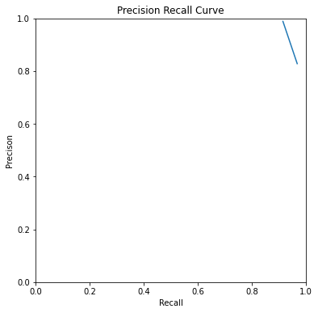

```python
grid_search_df.plot(x='Recall', y='Precision',
                    xlim=(0,1), ylim=(0,1),
                    xlabel='Recall', ylabel='Precison',
                    figsize=(6,6), legend=None,
                    title="Precision Recall Curve")
```

Turns out that the PSL model with its collective rules is pretty good at pushing the probabilities to the extremes (either 0 or 1), to the point that there there is no need to tweak the classification thresholds to improve the model. The default 0.5 threshold is as good as it gets already!

**Threshold-F1 Curve**

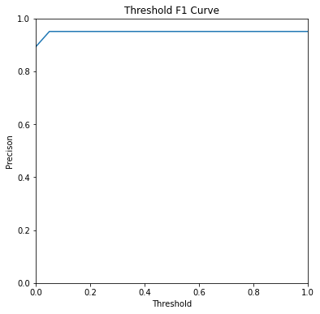

```python
grid_search_df.plot(y='F1 Score',
                    xlim=(0,1), ylim=(0,1),
                    xlabel='Threshold', ylabel='Precison',
                    figsize=(6,6), legend=None,
                    title="Threshold F1 Curve")
```

As expected from before: nothing to optimize here!

# The End

Matheus Schmitz  
[LinkedIn](https://www.linkedin.com/in/matheusschmitz/)  
[Github Portfolio](https://matheus-schmitz.github.io/)